# Lecture 7: The Lab Report

Analysing Data, Spring 2020

Dr Jennifer Mankin

# Overview

- Main ideas and requirements
- Tour of the lab report Markdown file and data
- What to include in each section
- How to write a discussion
- How the report will be marked

## Asking Questions

- Please go to pollev.com/drmankin and ask your questions there, or upvote other people’s questions
- If I run out of time, I will post answers on the Discussion board

# Main Ideas

- Imagine you have tried to **replicate** either the Red or Green study (your choice)
  - Same experiment design and materials/stimuli, same type of data
  - Recruited different people to participate
- Research question: is the red/green effect replicable?
  - Does it really exist?
  - How do your results compare to the original study?
  - What does this tell you about how people experience attraction, or how they decide what to buy?

## Main Ideas

- Second half of a report **only**
  - Methods, results, discussion, references
  - NO abstract or introduction
- You **must** use the data we give you!
  - Do not need to use or collect any data for or even mention the study you designed for PaaS

## Requirements

- Download [the report Markdown posted on Canvas](https://canvas.sussex.ac.uk/courses/9242/pages/Lab%20Report%20Information%20and%20Resources?titleize=0#creating)
- Edit, customise, and complete this document so that, **when knitted**, it produces a professional report no longer than 2000 words
- Submit the Markdown file on Canvas

### Details

- Formatting: Professional (i.e. like a report/journal article)
  - Consistent and sensible throughout
  - Colour in figures okay, but be reasonable
- APA style?
  - Reporting statistics, citations/references: YES
  - Headings, text formatting, etc.: NO

# Tour of the Markdown file

# What to Include

- Detailed instructions on [the Lab Report page on Canvas](https://canvas.sussex.ac.uk/courses/9242/pages/Lab%20Report%20Information%20and%20Resources?titleize=0#details)
- Methods
- Results
- Discussion
- References

## Methods

- A short participant description
- A succinct description of the variables and design

### Participants

Complete this section by including:

- The number of people who participated in the experiment initially
- The mean, standard deviation, and range of the participants’ ages
- How many people you removed, and for what reason(s)
- The final number of people whose data was included in your results
- A table of participant descriptives by experimental condition

### Design

Complete this section by including:

- A statement of the conceptual hypothesis/research question
- A description of the operationalisation of each variable, including:
  - Whether each variable was a factor, a rating, etc.
  - How each variable was measured, such as the levels (for factors) or range of possible scores (for ratings)
  - How to interpret each variable, such as what a high/low score means
- A clear and simple statement of the operational hypothesis
- What statistical analysis you will do to test this hypothesis

## Results

- Describe any changes or transformations of the data
- Report and interpret the general pattern of results
- Report and interpret the results of the statistical test
  - Use inline code for reporting
  - Advice on reporting/interpreting on [How to Get a First](https://canvas.sussex.ac.uk/courses/9242/pages/how-to-get-a-first)
- Include a figure that illustrates the effect of interest

### Red Study Results

- Describe any changes or transformations of the data
  - Mention the **composite score** and how it was calculated
- Report and interpret the general pattern of results
  - Means and SDs in each group, and what they mean
- Report and interpret the results of the statistical test
  - Independent measures *t*-test as in [the tutorial/practical in Week 7](https://canvas.sussex.ac.uk/courses/9242/pages/week-7)
- Include a figure that illustrates the effect of interest

### Red Study Figures

- Must represent the means and confidence intervals in each group
- Clearly and informatively labeled and coloured

#### Good Example: Colour

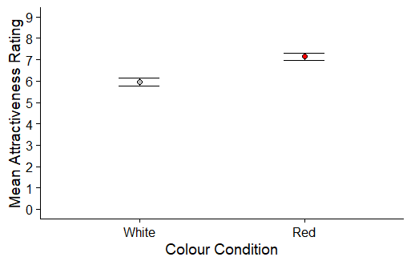

#### Good Example: Greyscale

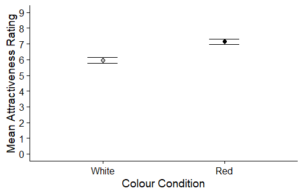

#### BAD Example

DO NOT USE BARS

- The Elliot et al. (2010) paper does…but you shouldn’t!

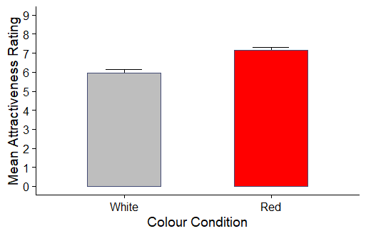

#### BAD Example: WHY

Please just don’t

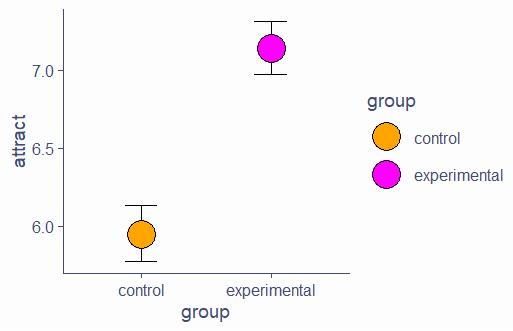

### Green Study Figures

Must represent the counts (or percentages) in each combination of categories

#### Good Example: Colour

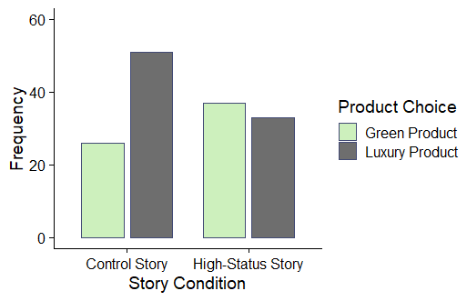

#### Good Example: Greyscale

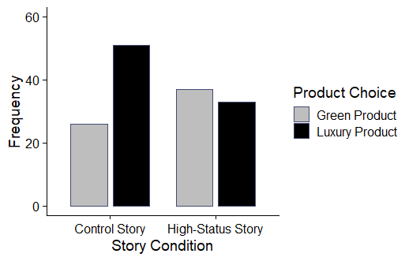

#### BAD Example

Please don’t make your marker cry

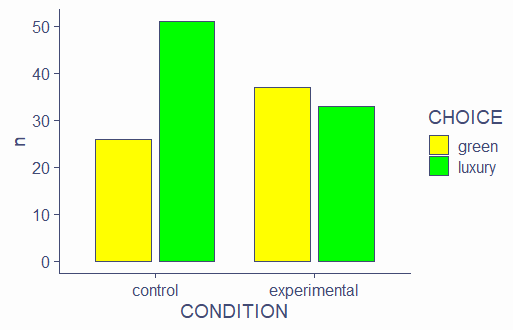

## Discussion

- A thorough exploration of what your results mean:
  - For your research question
  - In relation to the research field/future studies
- Should comprise at least half of the words in your report!
- More tips in just a moment

## References

- Formatted list of all of the references you cite in your report
  - Conform to [APA guidelines](https://owl.purdue.edu/owl/research_and_citation/apa_style/apa_formatting_and_style_guide/reference_list_basic_rules.html)
  - Use other resources (Google Scholar, Zotero, Mendeley, etc.) to help you build the reference list

### Hanging Indents

```
<p style="margin-left: 36px; text-indent: -36px;">Elliot, A. J., Niesta Kayser, D., Greitemeyer, T.,
Lichtenfeld, S., Gramzow, R. H., Maier, M. A., & Liu, H. (2010). Red, rank, and romance
in women viewing men. <i>Journal of Experimental Psychology: General, 139</i>(3), 399.</p>
```

Elliot, A. J., Niesta Kayser, D., Greitemeyer, T., Lichtenfeld, S., Gramzow, R. H., Maier, M. A., & Liu, H. (2010). Red, rank, and romance in women viewing men. *Journal of Experimental Psychology: General, 139*(3), 399.

## Summary

- Follow the directions in the Markdown document
- Do exactly what you’ve practiced in the tutorials/practicals
- Refer to the [Lab Report Information and Resources page](https://canvas.sussex.ac.uk/courses/9242/pages/lab-report-information-and-resources) for details!

# Writing Discussions

A good discussion includes the following elements:

- Summary
- Implications
- Limitations
- Future Research
- Conclusion

## Summary

- A summary of the main results in non-statistical language
  - Restate the research question
  - Explain how your statistical result answered the question
- You should be able to skip straight to this section (without reading the results) and still understand it!

## Implications

- A comparison between your results and other studies
  - Did you find the same pattern of results? What does this mean?
  - Did you find a different pattern of results? What does this mean?
- You **must** refer to evidence!
  - Describe and cite related studies

## Limitations

- An analysis of how any problems with the data/design/model/analysis have limited your findings
- Be specific - do not speculate!
  - Good: “Because of X, we found that our participants did Y, which means we are unable to comment on Q…”
  - Bad: “Our participants may have been bored so it could be that none of our results mean anything”
  - Also bad: “The study was not ecologically valid so the results are meaningless”

## Future Research

- Concrete, actionable suggestions for future studies, based on your own findings
  - Concrete: make specific suggestions with reference to evidence
  - Actionable: Realistic - someone could use your suggestion as the research question for their own study
  - Good: “Future studies may want to use a different rating scale, for example the one developed by Author et al. (year), to avoid X problem…”
  - Bad: “Future studies should investigate more options for different conditions.”
- You **must** refer to evidence!
  - Describe and cite related studies

## Conclusion

- A short paragraph recapping the main points: research question, result, main implications and next steps

## Discussion Summary

- Examine your results from every angle
  - What you **can** learn from your study
  - What you **can’t** learn (but would be good to know!)
- Cite evidence from other papers or your own data
- More resources: [Details on Discussions](https://canvas.sussex.ac.uk/courses/9242/pages/lab-report-information-and-resources#discussion) and [How to Get a First](https://canvas.sussex.ac.uk/courses/9242/pages/how-to-get-a-first)
- Read other papers and use them as examples!

# Marking

- Refer to [the marking information](https://canvas.sussex.ac.uk/courses/9242/pages/marking-and-feedback-information) (and link to marking criteria)